# MacroSignals — Vintage-Aware Macro Signal Research

Run-level research report

13 November 2026

**Data-quality gate:** PASS — publication allowed  
Run `run_20261113_c9f439e3` · as of 2026-11-13 · params hash `c9f439e3fc44`

# 1 Universe and data coverage

The committed research universe contains **16 instruments** across **3 asset classes** and **6 vintage-aware macro series**. The price panel covers 2018-11-01 to 2026-11-13 with 33,552 instrument-days. The vintage store holds 1,675 observation-vintage rows from 2018-01-31 to 2026-10-30.

Instrument coverage by asset class

| asset_class | instruments |
| --- | --- |
| Equity | 3 |
| FX | 8 |
| Rates | 5 |

Macro series and publication lags

| series_id | name | country | frequency | unit | publish_lag_days |
| --- | --- | --- | --- | --- | --- |
| EA_CPI | Euro area HICP (all items) | EA | monthly | index_2015_100 | 15 |
| EA_PMI | Euro area manufacturing PMI | EA | monthly | diffusion_index | 3 |
| JP_CPI | Japan CPI (all items) | JP | monthly | index_2015_100 | 18 |
| US_CPI | US CPI (all items) | US | monthly | index_2015_100 | 12 |
| US_PAYROLLS | US nonfarm payroll change | US | monthly | thousand_persons | 5 |
| US_PMI | US ISM manufacturing PMI | US | monthly | diffusion_index | 2 |

# 2 Validation summary

Each named check is run against the point-in-time view at the as-of date. Any `fail` blocks signal publication. This run recorded **0 validation rows**, **0 FAIL rows**.

Validation checks (no findings)

| check_name | severity | n |
| --- | --- | --- |
| all checks | pass | 0 |

```
## No validation findings: all six checks passed cleanly.
```

# 3 Signal distributions

Cross-sectional z-scores for the four published signals at every rebalance date. Winsorisation is applied at the 0.05 level before standardisation.

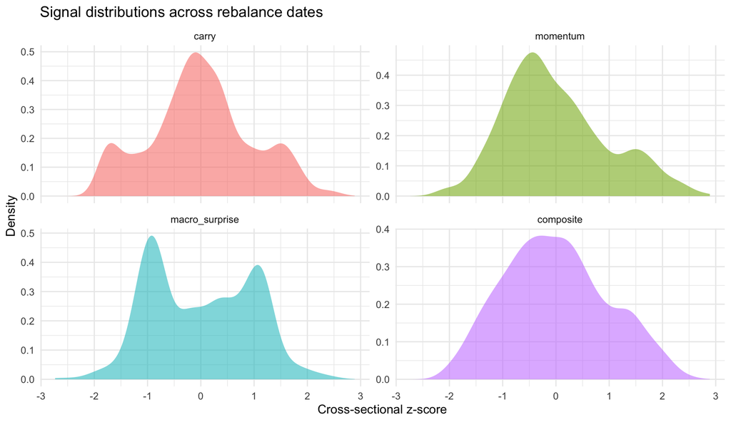

# 4 Equity curves

Net-of-cost cumulative PnL for each signal, with the configured one-way cost of 5 bp on traded notional.

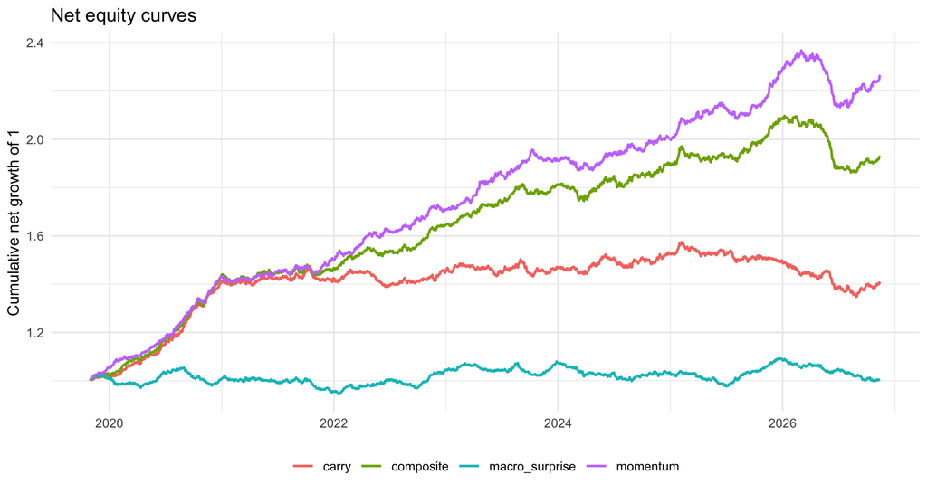

# 5 Drawdowns

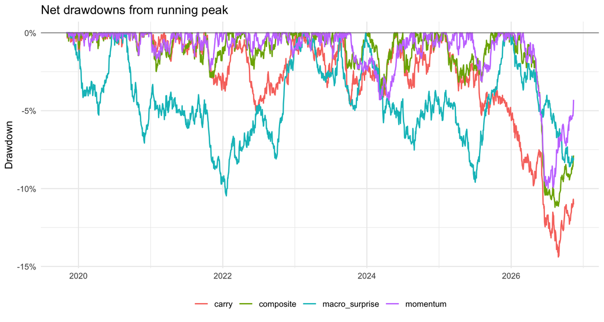

# 6 Performance and risk

Gross and net diagnostics. Max drawdown is reported with the peak-to-trough date range; turnover is annualised traded notional; holding period is the mean run length of a non-zero position in business days.

Net-of-cost metrics (5 bp)

| Signal | Ann. return | Ann. vol | Sharpe | Max DD | DD period | Calmar | Hit rate | Ann. turnover | Holding days |
| --- | --- | --- | --- | --- | --- | --- | --- | --- | --- |
| carry | 4.73% | 4.35% | 1.09 | -14.39% | 2025-02-06 → 2026-08-28 | 0.33 | 52.37% | 2.70 | 237.0 |
| momentum | 11.88% | 4.01% | 2.82 | -9.97% | 2026-03-03 → 2026-07-07 | 1.19 | 56.34% | 8.44 | 80.3 |
| macro_surprise | 0.06% | 4.02% | 0.03 | -10.47% | 2020-08-31 → 2022-01-19 | 0.01 | 50.19% | 6.99 | 92.2 |
| composite | 9.45% | 4.07% | 2.24 | -11.20% | 2026-01-07 → 2026-08-11 | 0.84 | 55.58% | 5.99 | 105.0 |

Gross (zero-cost) metrics

| Signal | Ann. return | Ann. vol | Sharpe | Max DD | Calmar | Ann. turnover |
| --- | --- | --- | --- | --- | --- | --- |
| carry | 4.88% | 4.35% | 1.12 | -14.24% | 0.34 | 2.70 |
| momentum | 12.35% | 4.00% | 2.93 | -9.80% | 1.26 | 8.44 |
| macro_surprise | 0.41% | 4.02% | 0.12 | -9.94% | 0.04 | 6.99 |
| composite | 9.78% | 4.07% | 2.32 | -10.96% | 0.89 | 5.99 |

# 7 Turnover and cost sensitivity

The grid reruns each strategy at one-way costs of 0, 1, 2, 5, 10, 20 bp. Net Sharpe is shown for the composite and each stand-alone signal.

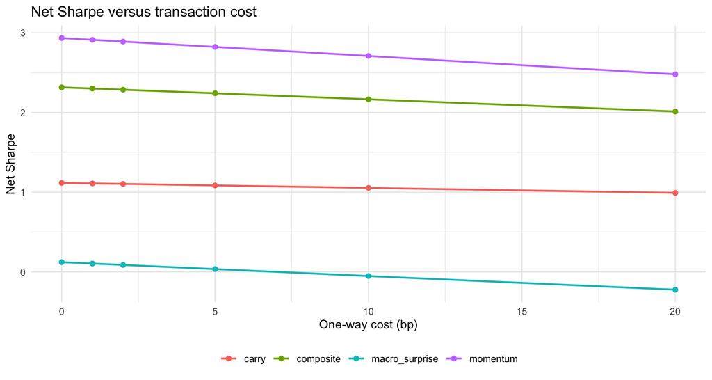

Cost-sensitivity grid (net)

| signal_name | ann_return_0bp | ann_return_1bp | ann_return_2bp | ann_return_5bp | ann_return_10bp | ann_return_20bp | sharpe_0bp | sharpe_1bp | sharpe_2bp | sharpe_5bp | sharpe_10bp | sharpe_20bp | ann_turnover_0bp | ann_turnover_1bp | ann_turnover_2bp | ann_turnover_5bp | ann_turnover_10bp | ann_turnover_20bp |
| --- | --- | --- | --- | --- | --- | --- | --- | --- | --- | --- | --- | --- | --- | --- | --- | --- | --- | --- |
| carry | 4.88% | 4.85% | 4.82% | 4.73% | 4.59% | 4.31% | 1.12 | 1.11 | 1.10 | 1.09 | 1.05 | 0.99 | 2.70 | 2.70 | 2.70 | 2.70 | 2.70 | 2.70 |
| momentum | 12.35% | 12.26% | 12.16% | 11.88% | 11.41% | 10.47% | 2.93 | 2.91 | 2.89 | 2.82 | 2.71 | 2.48 | 8.44 | 8.44 | 8.44 | 8.44 | 8.44 | 8.44 |
| macro_surprise | 0.41% | 0.34% | 0.27% | 0.06% | -0.29% | -0.99% | 0.12 | 0.10 | 0.09 | 0.03 | -0.05 | -0.22 | 6.99 | 6.99 | 6.99 | 6.99 | 6.99 | 6.99 |
| composite | 9.78% | 9.72% | 9.65% | 9.45% | 9.13% | 8.47% | 2.32 | 2.30 | 2.29 | 2.24 | 2.17 | 2.01 | 5.99 | 5.99 | 5.99 | 5.99 | 5.99 | 5.99 |

# 8 Latest ranked cross-section

Rank 1 is the most attractive composite signal at the final rebalance date.

Ranked signals as of 2026-11-13

| Rank | Instrument | Name | Class | Carry | Momentum | Macro surprise | Composite |
| --- | --- | --- | --- | --- | --- | --- | --- |
| 1 | USDJPY | US/JP spot | FX | 1.44 | 0.09 | 1.66 | 1.41 |
| 2 | USDCHF | US/CH spot | FX | 1.40 | 0.85 | -0.30 | 1.31 |
| 3 | JGB10Y | Japan 10y JGB future proxy | Rates | 0.90 | -0.46 | 2.35 | 1.31 |
| 4 | USDSEK | US/SE spot | FX | 1.05 | 0.58 | -0.30 | 0.90 |
| 5 | ACGB10Y | Australia 10y bond future proxy | Rates | 0.25 | 0.62 | NA | 0.69 |
| 6 | GILT10Y | UK 10y Gilt future proxy | Rates | 0.20 | 0.62 | NA | 0.63 |
| 7 | UST10Y | US 10y Treasury future proxy | Rates | 0.12 | 0.81 | -0.66 | 0.24 |
| 8 | USDCAD | US/CA spot | FX | -0.28 | 0.63 | -0.30 | 0.01 |
| 9 | BUND10Y | German 10y Bund future proxy | Rates | 0.50 | 0.11 | -1.15 | -0.13 |
| 10 | GBPUSD | GB/US spot | FX | -0.31 | 0.34 | -0.66 | -0.35 |
| 11 | AUDUSD | AU/US spot | FX | -0.30 | 0.21 | -0.66 | -0.42 |
| 12 | DAX40 | DAX 40 index future proxy | Equity | 0.39 | -1.89 | 1.08 | -0.46 |
| 13 | NDX100 | Nasdaq 100 index future proxy | Equity | -1.79 | 1.42 | -0.30 | -0.56 |
| 14 | EURUSD | EA/US spot | FX | -1.51 | -0.62 | 0.21 | -1.38 |
| 15 | NZDUSD | NZ/US spot | FX | -0.46 | -1.30 | -0.66 | -1.45 |
| 16 | SPX500 | S&P 500 index future proxy | Equity | -1.61 | -2.02 | -0.30 | -1.72 |

# 9 Reproducibility

Every number in this report was produced by `scripts/run_research.R` from the seeded deterministic fixtures. The parameter file is version controlled and its MD5 is recorded in the run summary.

```
## Run id           : run_20261113_c9f439e3
```

```
## As-of date       : 2026-11-13
```

```
## Params file      : config/params.yml
```

```
## Params MD5       : c9f439e3fc44c9408b5d3062e28198d1
```

```
## Fixture seed     : 20261114
```

```
## R version        : R version 4.6.1 (2026-06-24)
```

```
## Platform         : aarch64-apple-darwin25.4.0
```

```
## Rebalance        : monthly
```

```
## Cost (bp)        : 5
```

```
## Validation checks: 0 distinct findings; 0 FAIL rows
```

Version-controlled parameters

| parameter | value |
| --- | --- |
| seed | 20261114 |
| as_of | 2026-11-13 |
| start_date | 2018-11-01 |
| zscore.window | 252 |
| zscore.min_periods | 60 |
| zscore.winsor_level | 0.05 |
| momentum.lookbacks | 21, 63, 252 |
| momentum.weights | 0.3, 0.4, 0.3 |
| carry.smoothing | 5 |
| macro_surprise.trailing_months | 12 |
| macro_surprise.min_history | 6 |
| composite_weights.carry | 0.4 |
| composite_weights.momentum | 0.35 |
| composite_weights.macro_surprise | 0.25 |
| rebalance | monthly |
| cost_bp | 5 |
| cost_grid_bp | 0, 1, 2, 5, 10, 20 |
| validation.staleness_business_days.monthly | 45 |
| validation.staleness_business_days.daily | 5 |
| validation.gap_business_days.monthly | 62 |
| validation.gap_business_days.daily | 10 |
| validation.constant_lookback | 24 |
| validation.constant_tol | 1e-10 |
| validation.zscore_window | 60 |
| validation.zscore_outlier_k | 8 |
| validation.zscore_min_periods | 12 |
| validation.forbidden_future_vintages | TRUE |

[output not shown]

[output not shown]